# cm006 Exercises: Exploring Geometric Objects

In this worksheet, we'll be exploring various plot types (i.e., geometric objects), only using the `x` and `y` aesthetics (and `group`).

1. To get started, load the `tidyverse` and `gapminder` R packages.

```r
library(tidyverse)
library(gapminder)
```

## Scatterplot

Let's look at a *scatterplot* of `gdpPercap` vs. `lifeExp`.

1. Fill out the grammar components below. Again, bold *must* be specified to make a `ggplot2` plot.
   - We'll ignore "coordinate system" and "facetting" after this.

| Grammar Component | Specification |
| --- | --- |
| **data** | `gapminder` |
| **aesthetic mapping** | `x` and `y` |
| **geometric object** | points |
| scale | linear |
| statistical transform | none |
| coordinate system | rectangular |
| facetting | none |

1. Populate the data and aesthetic mapping in `ggplot`. What is returned? What's missing?

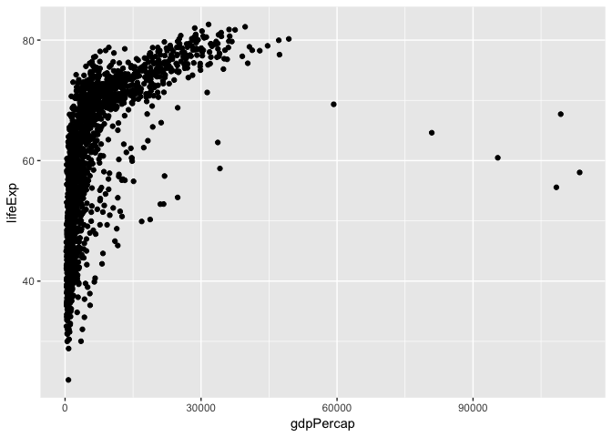

```r
ggplot(gapminder, aes(x=gdpPercap, y=lifeExp)) +
  geom_point()
```

1. Add the missing component as a *layer*.

Notice the "metaprogramming" again!

1. You *must* remember to put the aesthetic mappings in the `aes` function! What happens if you forget?

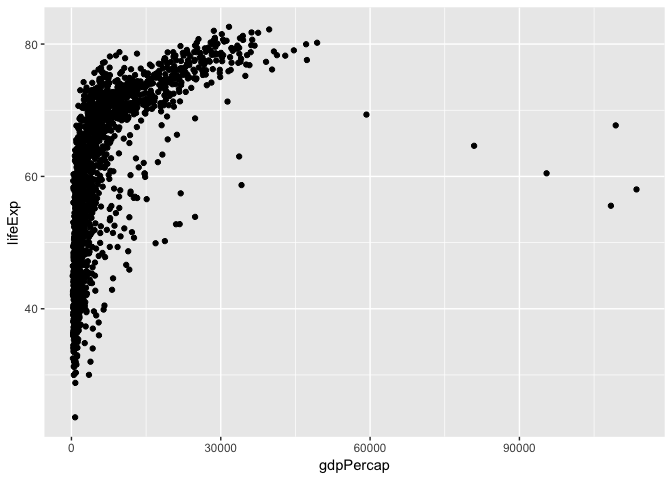

```r
ggplot(gapminder, aes(x=gdpPercap, y=lifeExp)) +
  geom_point()
```

1. Put the x-axis on a log scale, first by transforming the x variable.
   - Note: `ggplot2` does some data wrangling and computations itself! We don't always have to modify the data frame.

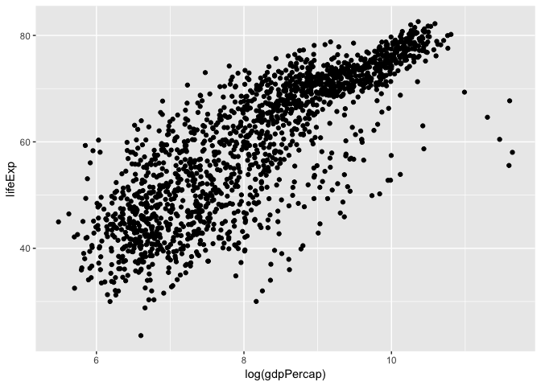

```r
ggplot(gapminder, aes(x=log(gdpPercap), y=lifeExp)) +
  geom_point()
```

1. Try again, this time by changing the *scale* (this way is better).

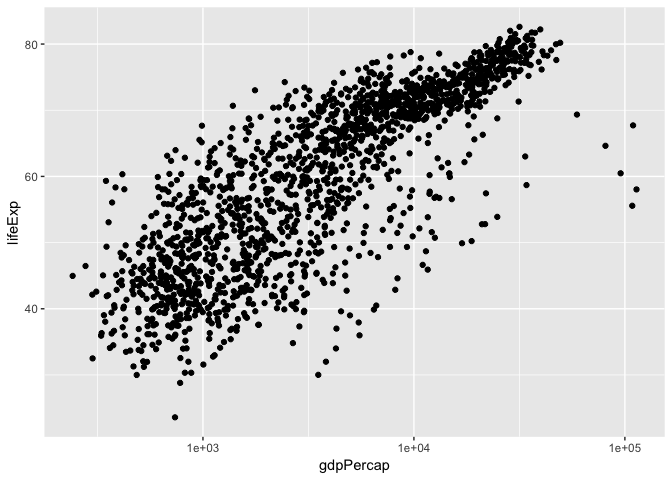

```r
ggplot(gapminder, aes(x=gdpPercap, y=lifeExp)) +
  geom_point() +
  scale_x_log10()
```

```r
gapminder %>%
  ggplot(aes(x=gdpPercap, y=lifeExp)) +
  geom_point()
```

[output not shown]